# Assignment 4, Revised Version

Yerin Jung

6/23/2018

# 1 Data

The data frame contains information regarding a national summary of inpatient charge data by Medicare severity diagnosis related group (MS-DRG), originally from [Data.CMS](https://data.cms.gov/Medicare-Inpatient/National-Summary-of-Inpatient-Charge-Data-by-Medic/efwk-h4x3).

# 2 Table

The following table shows the first 4 rows of the data frame.  
I changed the column names in a more convenient way to analyze.

| DRG_Def | Pro_Id | Pro_Name | Pro_Add | Pro_City | Pro_State | Pro_Zip | HRR | Tot_Discharges | Avg_Cov_Charges | Avg_Tot_Payments | Avg_Med_Payments |
| --- | --- | --- | --- | --- | --- | --- | --- | --- | --- | --- | --- |
| 001 - HEART TRANSPLANT OR IMPLANT OF HEART ASSIST SYSTEM W MCC | 10033 | UNIVERSITY OF ALABAMA HOSPITAL | 619 SOUTH 19TH STREET | BIRMINGHAM | AL | 35233 | AL - Birmingham | 11 | 1014783.4 | 171081.2 | 141193.9 |
| 001 - HEART TRANSPLANT OR IMPLANT OF HEART ASSIST SYSTEM W MCC | 30103 | MAYO CLINIC HOSPITAL | 5777 EAST MAYO BOULEVARD | PHOENIX | AZ | 85054 | AZ - Phoenix | 28 | 382051.0 | 194081.4 | 167512.0 |
| 001 - HEART TRANSPLANT OR IMPLANT OF HEART ASSIST SYSTEM W MCC | 50025 | UNIVERSITY OF CALIFORNIA SAN DIEGO MEDICAL CENTER | 200 WEST ARBOR DRIVE | SAN DIEGO | CA | 92103 | CA - San Diego | 21 | 971881.5 | 324050.7 | 294419.6 |
| 001 - HEART TRANSPLANT OR IMPLANT OF HEART ASSIST SYSTEM W MCC | 50100 | SHARP MEMORIAL HOSPITAL | 7901 FROST ST | SAN DIEGO | CA | 92123 | CA - San Diego | 18 | 1517857.6 | 257177.3 | 233532.8 |

The table below is a summary table of our dataset.  
We will walk through each column by column in the following parts.

|  | DRG_Def | Pro_Id | Pro_Name | Pro_Add | Pro_City | Pro_State | Pro_Zip | HRR | Tot_Discharges | Avg_Cov_Charges | Avg_Tot_Payments | Avg_Med_Payments |
| --- | --- | --- | --- | --- | --- | --- | --- | --- | --- | --- | --- | --- |
|  | Length:201876 | Min. : 10001 | Length:201876 | Length:201876 | Length:201876 | Length:201876 | Min. : 1040 | Length:201876 | Min. : 11.00 | Min. : 1715 | Min. : 2420 | Min. : 659.3 |
|  | Class :character | 1st Qu.:110079 | Class :character | Class :character | Class :character | Class :character | 1st Qu.:25301 | Class :character | 1st Qu.: 15.00 | 1st Qu.: 21735 | 1st Qu.: 6261 | 1st Qu.: 4982.4 |
|  | Mode :character | Median :240106 | Mode :character | Mode :character | Mode :character | Mode :character | Median :43725 | Mode :character | Median : 22.00 | Median : 36050 | Median : 9185 | Median : 7680.9 |
|  | NA | Mean :255739 | NA | NA | NA | NA | Mean :47051 | NA | Mean : 36.82 | Mean : 55009 | Mean : 13220 | Mean : 11213.9 |
|  | NA | 3rd Qu.:380027 | NA | NA | NA | NA | 3rd Qu.:71901 | NA | 3rd Qu.: 39.00 | 3rd Qu.: 63474 | 3rd Qu.: 14655 | 3rd Qu.: 12442.5 |
|  | NA | Max. :670100 | NA | NA | NA | NA | Max. :99801 | NA | Max. :3990.00 | Max. :2794184 | Max. :449486 | Max. :417977.3 |

First, `DRG_Def` represents classification system that groups similar clinical conditions (diagnoses) and  
the procedures furnished by the hospital during the stay. [Data.CMS](https://data.cms.gov/Medicare-Inpatient/National-Summary-of-Inpatient-Charge-Data-by-Medic/efwk-h4x3)

| DRG_Def | Pro_Id | Pro_Name | Pro_Add | Pro_City | Pro_State | Pro_Zip | HRR | Tot_Discharges | Avg_Cov_Charges | Avg_Tot_Payments | Avg_Med_Payments |
| --- | --- | --- | --- | --- | --- | --- | --- | --- | --- | --- | --- |
| 001 - HEART TRANSPLANT OR IMPLANT OF HEART ASSIST SYSTEM W MCC | 10033 | UNIVERSITY OF ALABAMA HOSPITAL | 619 SOUTH 19TH STREET | BIRMINGHAM | AL | 35233 | AL - Birmingham | 11 | 1014783 | 171081.2 | 141193.9 |
| 001 - HEART TRANSPLANT OR IMPLANT OF HEART ASSIST SYSTEM W MCC | 30103 | MAYO CLINIC HOSPITAL | 5777 EAST MAYO BOULEVARD | PHOENIX | AZ | 85054 | AZ - Phoenix | 28 | 382051 | 194081.4 | 167512.0 |

Second, `Pro_Id` stands for the id number of each provider(hospital).  
This can be a key value for further analyses.

| DRG_Def | Pro_Id | Pro_Name | Pro_Add | Pro_City | Pro_State | Pro_Zip | HRR | Tot_Discharges | Avg_Cov_Charges | Avg_Tot_Payments | Avg_Med_Payments |
| --- | --- | --- | --- | --- | --- | --- | --- | --- | --- | --- | --- |
| 001 - HEART TRANSPLANT OR IMPLANT OF HEART ASSIST SYSTEM W MCC | 10033 | UNIVERSITY OF ALABAMA HOSPITAL | 619 SOUTH 19TH STREET | BIRMINGHAM | AL | 35233 | AL - Birmingham | 11 | 1014783 | 171081.2 | 141193.9 |
| 001 - HEART TRANSPLANT OR IMPLANT OF HEART ASSIST SYSTEM W MCC | 30103 | MAYO CLINIC HOSPITAL | 5777 EAST MAYO BOULEVARD | PHOENIX | AZ | 85054 | AZ - Phoenix | 28 | 382051 | 194081.4 | 167512.0 |

Third, `Pro_Name`, `Pro_Add`, `Pro_City`, `Pro_State`, `Pro_Zip`, and `HRR` represent information of the providers.

| DRG_Def | Pro_Id | Pro_Name | Pro_Add | Pro_City | Pro_State | Pro_Zip | HRR | Tot_Discharges | Avg_Cov_Charges | Avg_Tot_Payments | Avg_Med_Payments |
| --- | --- | --- | --- | --- | --- | --- | --- | --- | --- | --- | --- |
| 001 - HEART TRANSPLANT OR IMPLANT OF HEART ASSIST SYSTEM W MCC | 10033 | UNIVERSITY OF ALABAMA HOSPITAL | 619 SOUTH 19TH STREET | BIRMINGHAM | AL | 35233 | AL - Birmingham | 11 | 1014783 | 171081.2 | 141193.9 |
| 001 - HEART TRANSPLANT OR IMPLANT OF HEART ASSIST SYSTEM W MCC | 30103 | MAYO CLINIC HOSPITAL | 5777 EAST MAYO BOULEVARD | PHOENIX | AZ | 85054 | AZ - Phoenix | 28 | 382051 | 194081.4 | 167512.0 |

Fourth, `Tot_Discharges` represents The number of discharges billed by all providers for inpatient hospital services. [Data.CMS](https://data.cms.gov/Medicare-Inpatient/National-Summary-of-Inpatient-Charge-Data-by-Medic/efwk-h4x3)

| DRG_Def | Pro_Id | Pro_Name | Pro_Add | Pro_City | Pro_State | Pro_Zip | HRR | Tot_Discharges | Avg_Cov_Charges | Avg_Tot_Payments | Avg_Med_Payments |
| --- | --- | --- | --- | --- | --- | --- | --- | --- | --- | --- | --- |
| 001 - HEART TRANSPLANT OR IMPLANT OF HEART ASSIST SYSTEM W MCC | 10033 | UNIVERSITY OF ALABAMA HOSPITAL | 619 SOUTH 19TH STREET | BIRMINGHAM | AL | 35233 | AL - Birmingham | 11 | 1014783 | 171081.2 | 141193.9 |
| 001 - HEART TRANSPLANT OR IMPLANT OF HEART ASSIST SYSTEM W MCC | 30103 | MAYO CLINIC HOSPITAL | 5777 EAST MAYO BOULEVARD | PHOENIX | AZ | 85054 | AZ - Phoenix | 28 | 382051 | 194081.4 | 167512.0 |

Fifth, `Avg_Cov_Charges` represents The average charge of all provider’s services covered by Medicare for discharges in the DRG.  
These will vary from hospital to hospital because of differences in hospital charge structures. [Data.CMS](https://data.cms.gov/Medicare-Inpatient/National-Summary-of-Inpatient-Charge-Data-by-Medic/efwk-h4x3)

| DRG_Def | Pro_Id | Pro_Name | Pro_Add | Pro_City | Pro_State | Pro_Zip | HRR | Tot_Discharges | Avg_Cov_Charges | Avg_Tot_Payments | Avg_Med_Payments |
| --- | --- | --- | --- | --- | --- | --- | --- | --- | --- | --- | --- |
| 001 - HEART TRANSPLANT OR IMPLANT OF HEART ASSIST SYSTEM W MCC | 10033 | UNIVERSITY OF ALABAMA HOSPITAL | 619 SOUTH 19TH STREET | BIRMINGHAM | AL | 35233 | AL - Birmingham | 11 | 1014783 | 171081.2 | 141193.9 |
| 001 - HEART TRANSPLANT OR IMPLANT OF HEART ASSIST SYSTEM W MCC | 30103 | MAYO CLINIC HOSPITAL | 5777 EAST MAYO BOULEVARD | PHOENIX | AZ | 85054 | AZ - Phoenix | 28 | 382051 | 194081.4 | 167512.0 |

Sixth, `Avg_Tot_Payments` shows The average total payments to all providers for the DRG including the MS-DRG amount, teaching, disproportionate share, capital, and outlier payments for all cases. [Data.CMS](https://data.cms.gov/Medicare-Inpatient/National-Summary-of-Inpatient-Charge-Data-by-Medic/efwk-h4x3)

| DRG_Def | Pro_Id | Pro_Name | Pro_Add | Pro_City | Pro_State | Pro_Zip | HRR | Tot_Discharges | Avg_Cov_Charges | Avg_Tot_Payments | Avg_Med_Payments |
| --- | --- | --- | --- | --- | --- | --- | --- | --- | --- | --- | --- |
| 001 - HEART TRANSPLANT OR IMPLANT OF HEART ASSIST SYSTEM W MCC | 10033 | UNIVERSITY OF ALABAMA HOSPITAL | 619 SOUTH 19TH STREET | BIRMINGHAM | AL | 35233 | AL - Birmingham | 11 | 1014783 | 171081.2 | 141193.9 |
| 001 - HEART TRANSPLANT OR IMPLANT OF HEART ASSIST SYSTEM W MCC | 30103 | MAYO CLINIC HOSPITAL | 5777 EAST MAYO BOULEVARD | PHOENIX | AZ | 85054 | AZ - Phoenix | 28 | 382051 | 194081.4 | 167512.0 |

Finally, `Avg_Med_Payment` represents The average amount that Medicare pays to the provider for Medicare’s share of the MS-DRG.  
[Data.CMS](https://data.cms.gov/Medicare-Inpatient/National-Summary-of-Inpatient-Charge-Data-by-Medic/efwk-h4x3)

| DRG_Def | Pro_Id | Pro_Name | Pro_Add | Pro_City | Pro_State | Pro_Zip | HRR | Tot_Discharges | Avg_Cov_Charges | Avg_Tot_Payments | Avg_Med_Payments |
| --- | --- | --- | --- | --- | --- | --- | --- | --- | --- | --- | --- |
| 001 - HEART TRANSPLANT OR IMPLANT OF HEART ASSIST SYSTEM W MCC | 10033 | UNIVERSITY OF ALABAMA HOSPITAL | 619 SOUTH 19TH STREET | BIRMINGHAM | AL | 35233 | AL - Birmingham | 11 | 1014783 | 171081.2 | 141193.9 |
| 001 - HEART TRANSPLANT OR IMPLANT OF HEART ASSIST SYSTEM W MCC | 30103 | MAYO CLINIC HOSPITAL | 5777 EAST MAYO BOULEVARD | PHOENIX | AZ | 85054 | AZ - Phoenix | 28 | 382051 | 194081.4 | 167512.0 |

# 3 Columns

First of all, I will parse the numbers from Drug definition to see graphs effectively

```r
payment <- parse_num(payment)
```

I decided to examine four quantitative comluns(`Tot_Discharges`, `Avg_Cov_Charges`, `Avg_Tot_Payments`, and `Avg_Med_Payments`) and one qualitative column(`Pro_State`).

## 3.1 Tot_Discharges

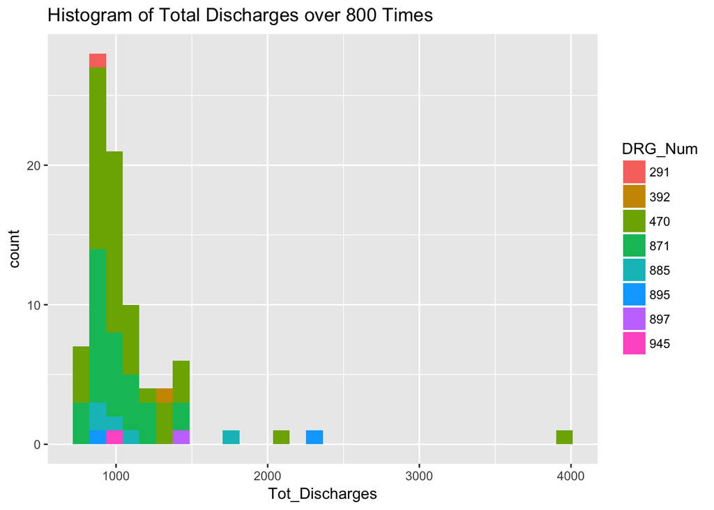

As we can see from the above chart, drug number $470$ and $871$ tended to be discharged more than the other drug definitions.  
The information about the two drug-definitions are as follows:

- 470 : MAJOR JOINT REPLACEMENT OR REATTACHMENT OF LOWER EXTREMITY W/O MCC
  - 871 : SEPTICEMIA OR SEVERE SEPSIS W/O MV 96+ HOURS W MCC

## 3.2 Avg_Cov_Charges, Avg_Tot_Payments, and Avg_Med_Payments

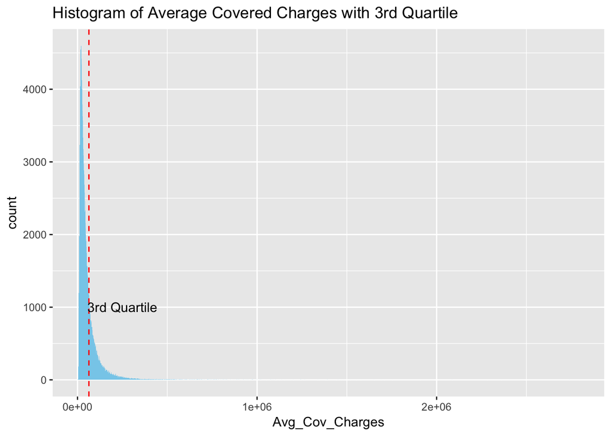

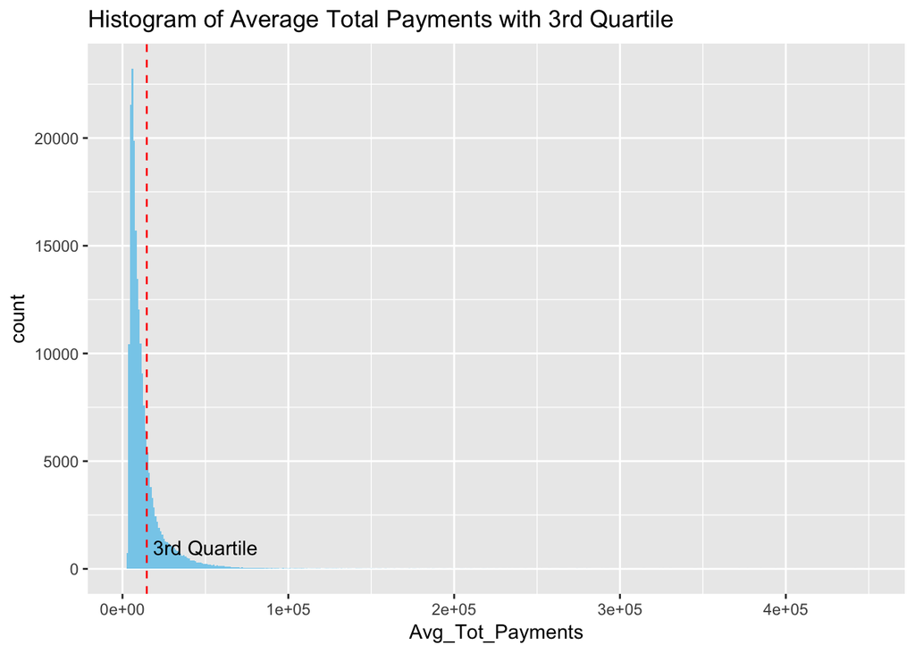

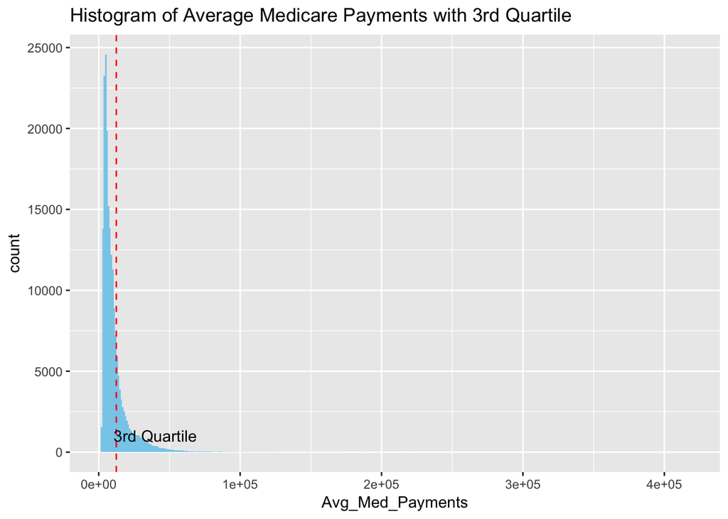

As we can see from the above three charts, all the variables are highly right-skewed.  
Since all the drug definitions have different charges, we might need to group them by drug group and state as well.

## 3.3 Pro_State

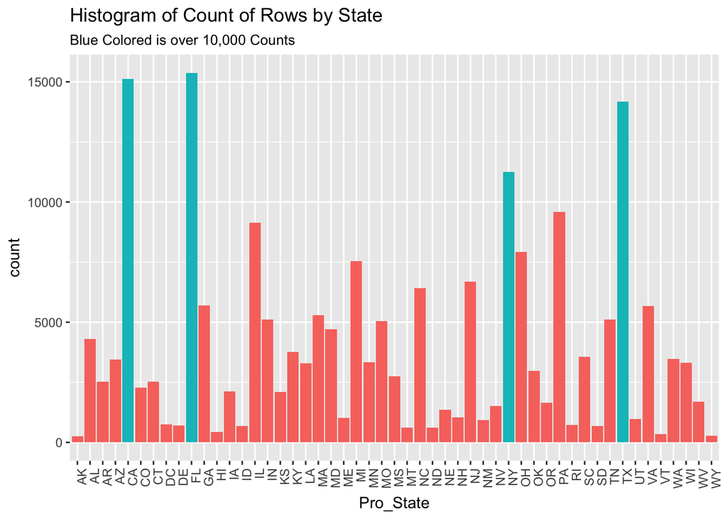

In the above chart, the states that have more than $10,000$ counts were colored by blue.  
I assume that they have more counts of rows just because they are the top four states in population ranking.

# 4 New Features

## 4.1 Comparing Standardized Total Payment

### 4.1.1 Lead

Generally, total payment of a care depends on the **region(state)** and type of **drug function**.  
As such, to see whether there is abnormally high total payment (`Avg_Tot_Payments`), I decided to standardize the value, using the mean and standard deviation of `Avg_Tot_Payments` grouped by Drug Definition (`Drug_Num`) and Provider State (`Pro_State`).

### 4.1.2 EDA

To do so, first, I should count the number of providers in each drug definition group.  
If there are just a few numbers of providers in the group, it might be less rational to compare the total payments.  
(In many cases there was only one provider in a drug function group.)

```r
# Making groups dependin on the number of providers in each drug group
payment1 <- group_class(payment)
```

Here, as I mentioned, I divided the dataset into three groups: `1_to_945`, `946_to_1890`, and `1890_to_2837`:  
- `1_to_945`: The number of entities in a drug definition group (`DRG_Def`) is a range of 1 to 946  
- `946_to_1890`: The number of entities in a drug definition group (`DRG_Def`) is a range of 946 to 1890  
- `1890_to_2837`: The number of entities in a drug definition group (`DRG_Def`) is a range of 1890 to 2837

| DRG_Def | n_row_group | group_class |
| --- | --- | --- |
| 906 - HAND PROCEDURES FOR INJURIES | 1 | 1_to_945 |
| 915 - ALLERGIC REACTIONS W MCC | 1 | 1_to_945 |
| 927 - EXTENSIVE BURNS OR FULL THICKNESS BURNS W MV >96 HRS W SKIN GRAFT | 1 | 1_to_945 |
| 950 - AFTERCARE W/O CC/MCC | 1 | 1_to_945 |
| 951 - OTHER FACTORS INFLUENCING HEALTH STATUS | 1 | 1_to_945 |
| 989 - NON-EXTENSIVE O.R. PROC UNRELATED TO PRINCIPAL DIAGNOSIS W/O CC/MCC | 1 | 1_to_945 |

As we can see from the above table, there are certain drug definition groups that have only one entity(case).

Then, I plotted `Avg_Tot_Payments` from only `1890_to_2837` group, to see the general trends as follows.

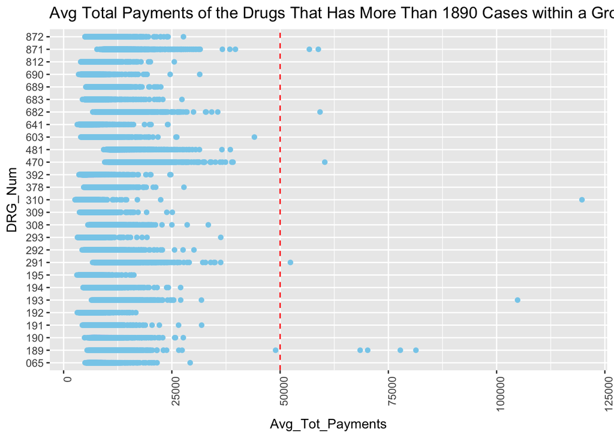

It looks like we see some outliers, though, we should not be so sure, since the price can also vary from states.

```r
# Making Three Columns after grouping by DRG_Num and Pro_State
payment1<-add_standard_payment(payment1)
```

I generated three columns as follows:  
- `Mu_DRG_State_Total_Payment`: Mean of `Avg_Tot_Payments` grouped by drug group (`Drug_Num`) and state (`Prov_State`).  
- `Sd_DRG_State_Total_Payment`: Standard deviation of `Avg_Tot_Payments` grouped by drug group (`Drug_Num`) and state (`Prov_State`).  
- `Std_DRG_State_Total_Payment`: Standardized `Avg_Tot_Payments` using Z-score with `Mu_DRG_State_Total_Payment` and `Sd_DRG_State_Total_Payment`

$$Z=\frac{X-\mu }{\sigma }=\frac{AvgTotalPayments-Mu(AvgTotalPayments)}{Sd(AvgTotalPayments)}$$

| DRG_Num | Pro_State | Mu_DRG_State_Total_Payment | Sd_DRG_State_Total_Payment | Std_DRG_State_Total_Payment |
| --- | --- | --- | --- | --- |
| 310 | AL | 3563.514 | 483.674 | -0.1821150 |
| 310 | AL | 3563.514 | 483.674 | -0.2088065 |
| 310 | AL | 3563.514 | 483.674 | -0.7699902 |
| 310 | AL | 3563.514 | 483.674 | -0.5502762 |
| 310 | AL | 3563.514 | 483.674 | 0.4886880 |
| 310 | AL | 3563.514 | 483.674 | -0.9001192 |

## 4.2 Conclusion

After dividing into three group depending on the number of providers in drug_definition,  
I filtered only the second and third group, which basically have more than 946 providers in each drug definition group.

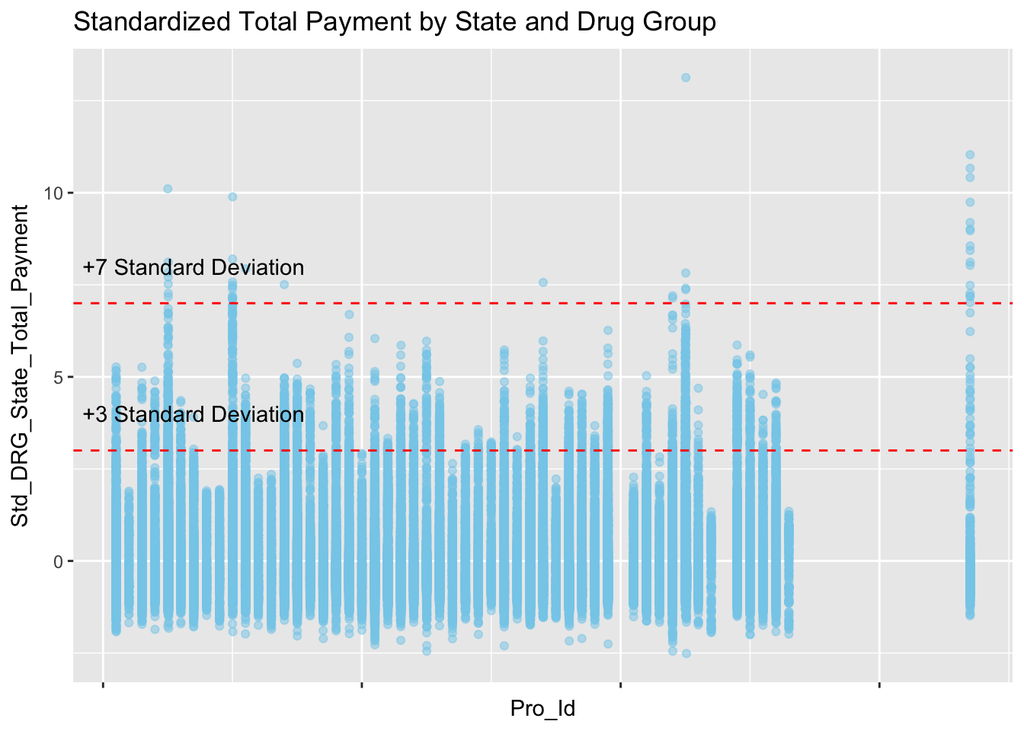

As we can see from the above graph, we can notice a few distinctively high standardized values, comparing to the other providers. We might want to further exam those values.  
Since they were outliers even after they were standardized by the mean grouped by state and drug as well, I believe that it has room to be a fraud case.

## 4.3 Standardized Difference Between Medical Coverage and Medical Payment

### 4.3.1 Lead

Since `Average Covered Charges` would vary from hospital to hospital, we should not simply assume a fraud, just because a provider overly charged Medicare to pay than they were supposed to cover.  
However, we can calculate the mean difference of `Average Covered Charges` and `Average Medicare Payments` per each Drug group, and see whether an entity has significant difference than the other in the same group.

### 4.3.2 EDA

```r
# Making Four New Columns
payment2<-add_standard(payment1)
```

$$Z=\frac{X-\mu }{\sigma }=\frac{DiffMedCovMedPay-MuDiff}{Sd_Diff}$$

This table below shows the examples of how standardized difference looks like.

| DRG_Num | Diff_MedCov_MedPay | Mu_Diff | Sd_Diff | Standard_Diff |
| --- | --- | --- | --- | --- |
| 001 | 873589.5 | 741484.5 | 441045.3 | 0.2995271 |
| 001 | 214539.0 | 741484.5 | 441045.3 | -1.1947648 |
| 001 | 677461.9 | 741484.5 | 441045.3 | -0.1451611 |
| 001 | 1284324.8 | 741484.5 | 441045.3 | 1.2308038 |
| 001 | 1131869.1 | 741484.5 | 441045.3 | 0.8851347 |
| 001 | 1046181.8 | 741484.5 | 441045.3 | 0.6908526 |

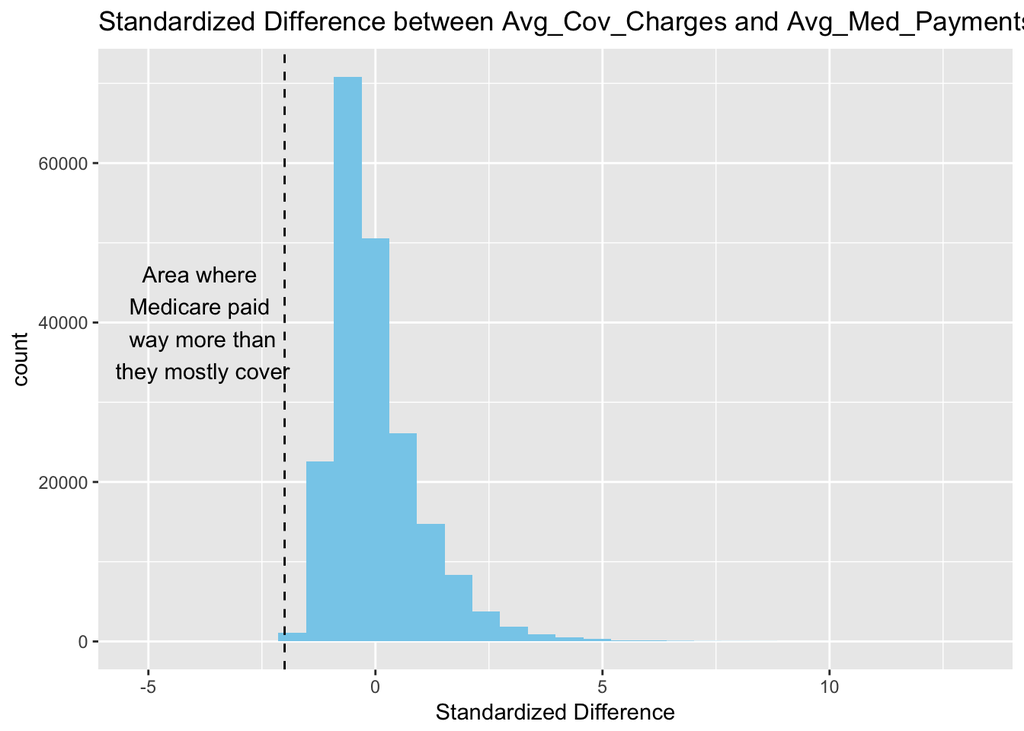

## 4.4 Conclusion

As such, I looked at the providers with the standardized difference even less than -2.

| DRG_Num | Pro_Id | Avg_Cov_Charges | Avg_Med_Payments | Standard_Diff |
| --- | --- | --- | --- | --- |
| 060 | 190098 | 8031.73 | 7872.80 | -2.294081 |
| 191 | 50373 | 16165.18 | 25440.91 | -2.015600 |
| 227 | 330204 | 27817.91 | 62671.73 | -2.064512 |
| 228 | 240010 | 121708.14 | 62987.19 | -2.080739 |
| 247 | 330128 | 23774.83 | 25166.06 | -2.071884 |
| 247 | 330204 | 26902.86 | 26728.09 | -2.026768 |
| 652 | 210002 | 92689.72 | 79761.80 | -2.051449 |
| 652 | 210009 | 144982.28 | 128110.99 | -2.009393 |
| 743 | 190128 | 21031.00 | 36138.74 | -2.283680 |
| 743 | 450674 | 41911.45 | 66521.18 | -2.759642 |
| 775 | 190128 | 9914.00 | 40970.00 | -4.834590 |
| 781 | 450674 | 45574.87 | 83661.93 | -2.786989 |
| 894 | 50543 | 10716.86 | 28666.59 | -3.041616 |
| 894 | 230275 | 1715.00 | 19729.37 | -3.050006 |
| 897 | 50543 | 11885.44 | 29827.84 | -2.350421 |
| 897 | 230275 | 4087.22 | 21698.11 | -2.328666 |
| 897 | 390025 | 5699.35 | 24106.39 | -2.380912 |

## 4.5 Number of Discharges

### 4.5.1 Lead

I would like to examine the number of discharges by drug and state, to detect unbundling.  
I believe that this feature can be powerful to detect anomalies when it is combined with the previously defined columns.

### 4.5.2 EDA

First, I made `Mean_Discharge` and `Stdv_Discharges` to eventually create `Standardized_Discharges` column.  
`Standardized_Discharges` column represents the standardized value of the number of discharges, grouped by drug and state.

```r
payment3 <- add_standard2(payment2)
```

We can check the standardized values from the below chart.

| DRG_Num | Pro_Id | Tot_Discharges | Standardized_Discharges |
| --- | --- | --- | --- |
| 987 | 240057 | 11 | -0.7395442 |
| 987 | 250078 | 12 | -0.7071068 |
| 987 | 250102 | 20 | 0.7071068 |
| 987 | 260032 | 26 | 1.1338934 |
| 987 | 260096 | 11 | -0.7559289 |
| 987 | 260108 | 14 | -0.3779645 |

Next, I looked at the histogram of the standardized number of discharges.  
We can see that they are right-skewed.

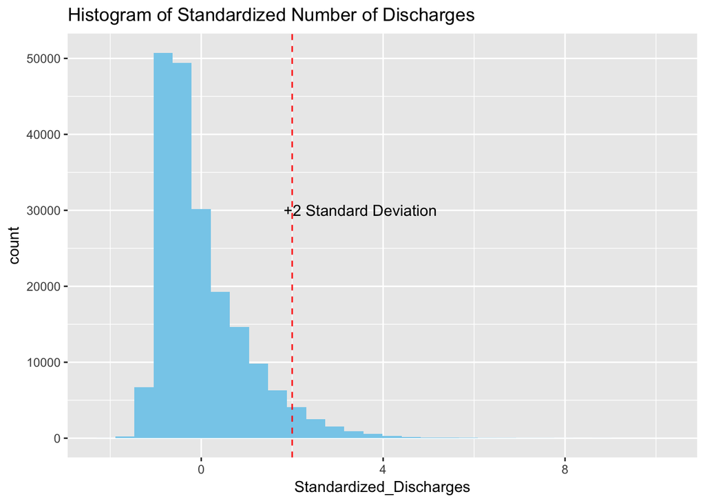

Finally, I combined the standardized number of discharges and the standardized difference. (`Standardized_Discharges` and`Standard_Diff`) and plotted as follows.

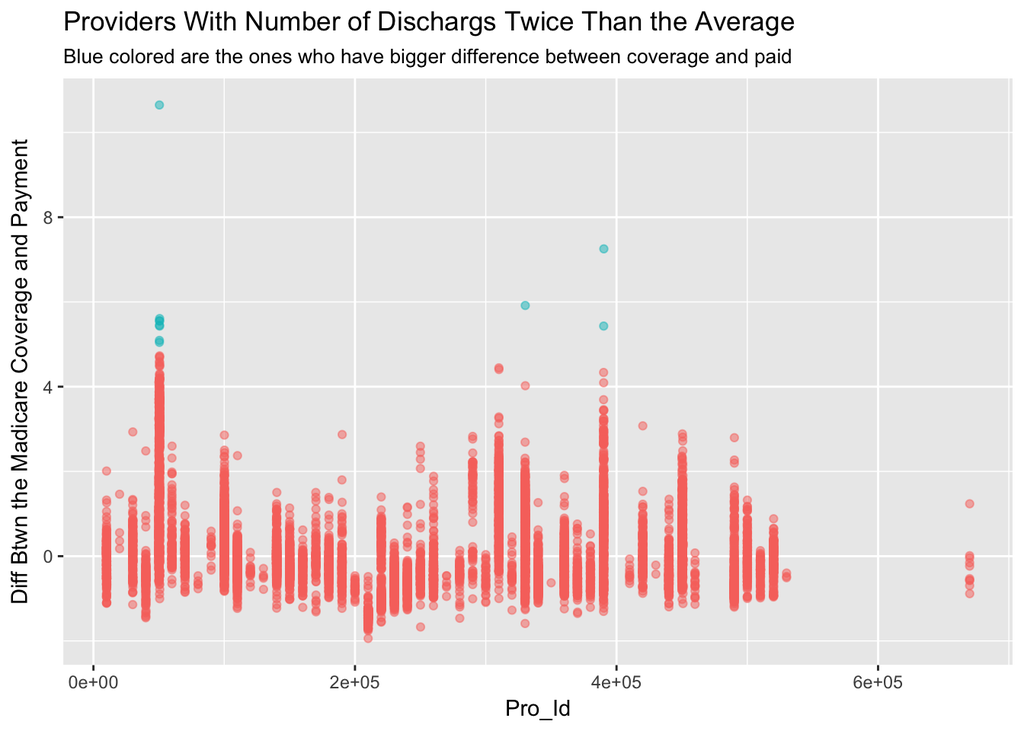

As we can see from the above graph, there were several providers with high `Standardized_Discharges`, and high `Standard_Diff` as well.  
(Those points have more than 2 `Standardized_Discharges`)

### 4.5.3 Conclusion

Since those $11$ cases are where the difference between Medicare coverage and Medicare payment is huge, and where more discharges happened as well, we might want to further examine those anomalies.

| DRG_Num | Pro_Id | Standardized_Discharges | Standard_Diff |
| --- | --- | --- | --- |
| 003 | 50625 | 2.602768 | 5.430464 |
| 074 | 390290 | 5.601616 | 7.252538 |
| 101 | 330214 | 5.573949 | 5.916512 |
| 177 | 390164 | 2.392107 | 5.430926 |
| 206 | 50441 | 2.413592 | 10.647811 |
| 246 | 50625 | 6.548840 | 5.548275 |
| 247 | 50625 | 4.186539 | 5.608008 |
| 292 | 50441 | 2.198379 | 5.558162 |
| 315 | 50441 | 3.027563 | 5.092814 |
| 326 | 50441 | 2.179774 | 5.046248 |
| 948 | 50441 | 2.142012 | 5.449465 |